**CSE2215** - Computer Graphics

Elmar Eisemann, Martin Skrodzki, Mathijs Molenaar, Michael Weinmann, Ricardo Marroqium

# Transformations

In this week’s practical we will look at using matrices to describe, combine and apply transformations. The practical is divided into two parts: a maze and a amusement park ride. Both exercises require you to apply rotation, scale and translation operations in the correct order to achieve the desired transformation.

### Rules

For this practical the following rules apply:

**General**

- We strongly recommend to do the assignment **individually**.
- This practical will help you prepare for the programming exam.
- We ask you to give the practical a try yourself to see whether you can solve it. Remember that the programming exam will also be an individual assessment.
- As always, you can approach the TAs with questions during the lab sessions.
- Your should compile your code **on Windows with Visual Studio 2022** (using the default MSVC toolchain). Otherwise, the TAs might not be able to help you with related issues.
- Submission on Brightspace is not required for this practical.

**Evaluation**

- This practical is ungraded.
- We provide you with a unit test framework using the [Catch2](https://github.com/catchorg/Catch2/) under `tests` for you to self-test your solutions.
- To use the test framework, select and build the target `Bachelor_Practical2_MazeTests` and `Bachelor_Practical2_AmusementParkTests`.
- You may extend the unit tests by changing `tests/src/maze.cpp` and `tests/src/amusement_park.cpp`.
- If it prints “xxx failed”, it means some of your solutions are incorrect. See the error messages in the console for a detailed explanation.
- If it prints “All tests passed”, you are good to go!

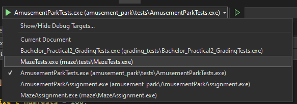

Selecting the testing executable

## OpenGL Math Library

In the C++ introduction practical you implemented a matrix and vector class. In this practical we will use the [glm](https://glm.g-truc.net/0.9.9/index.html) library to do this for us. `glm` provides 2D, 3D and 4D vectors and matrices as well as many operations that can be applied to these types.

We can create a 2D/3D/4D `glm` vector in various ways:

```cpp
glm::vec3 myFirstVec3 { 1, 2, 3 }; // Creates a vector (1, 2, 3)
glm::vec3 singleValueVec3 { 5 }; // Creates a vector (5, 5, 5)

glm::vec2 multiValueVec2 { 1, 2 }; // Creates a vector (1, 2)
glm::vec3 multiValueVec3 { myFirstVec2, 3 }; // Creates a vector (1, 2, 3)
glm::vec4 multiValueVec4 { multiValueVec3, 4 }; // Creates a vector (1, 2, 3, 4)
```

The glm library makes use of operator overloading. Operator overloading is a powerfull feature in c++ which allows us (or in this case `glm`) to define the behavior of the `+`, `-`, `*` and `/` operands for a custom class. In practice, this means that math heavy code is greatly simplified.

```cpp
glm::vec3 a { 2, 5, 3 };
glm::vec3 b { 9, -3, -1 };
glm::vec3 c = a + b; // (11, 2, 2)
```

`glm` provides functions to create transformations such as rotation, translation and scale. These functions take an existing matrix, compute the desired transformation matrix and multiply it by the existing matrix. The multiplication order is such that the transform operation is performed *before* the transformation stored in the input matrix.

```cpp
// Create an identity matrix (1 on the diagonal, 0 everywhere else).
glm::mat4 identity = glm::identity<glm::mat4>();

float angle = glm::radians(45.0f); // Convert angle from degrees to radians.
glm::vec3 axis { 0, 1, 0 }; // Positive y-axis
// Rotate around the positive y-axis by 45 degrees
glm::mat4 rotation = glm::rotate(identity, angle, axis);

// Translate by (1, 2, 3) *then* rotate around the positive y-axis by 45 degrees.
glm::mat4 translateThenRotate = glm::translate(rotation, glm::vec3(1, 2, 3));

// Scale by (1, 2, 3) *then* rotate around the positive y-axis by 45 degrees.
glm::mat4 scaleThenRotate = glm::scale(rotation, glm::vec3(1, 2, 3));

// Multiply the vector (0, 1, 2, 1) in homogenous coordinates by the scale/rotate matrix.
glm::vec4 resultHomogeneous = scaleThenRotate * glm::vec4(0, 1, 2, 1);
// Convert from homogenous coordinates back to cartesian coordinates.
glm::vec3 result = glm::vec3(resultHomogeneous) / resultHomogeneous.w;
```

We provide a couple of helper functions which compute the rotation / translation / scale matrices directly. Using these functions is **optional** but it allows you to write matrix multiplications in right to left order which is common in mathematical literature.

```cpp
glm::mat4 rotationMatrix(float angle, const glm::vec3& axis);
glm::mat4 translationMatrix(const glm::vec3& translation);
glm::mat3 rotationMatrix(float angle)
glm::mat3 translationMatrix(const glm::vec2& translation);

float angle = glm::radians(45.0f); // Convert angle from degrees to radians.
glm::vec3 axis { 0, 1, 0 }; // Positive y-axis
glm::mat4 translateThenRotate = rotationMatrix(angle, axis) * translationMatrix(glm::vec3(1, 2, 3));
```

You can find the full `glm` manual [here](https://github.com/g-truc/glm/blob/0.9.9.2/doc/manual.pdf).

## 1. Maze (3 points)

In this first exercise we will create a simple top-down 2D game of a crab finding it’s way through a forest to the water. The forest acts like a maze for the player to navigate through. The crab moves through three simple commands: turn left by 90 degrees, turn right by 90 degrees, move forward by 1 unit. You can replay the movements from the start to the goal as an animation by pressing the “Play” button, or by dragging the animation slider.

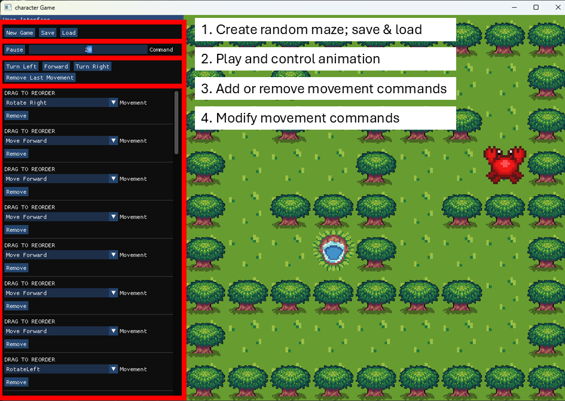

Maze - Graphics User Interface

When it is detected that the crab is moving through terrain, it will turn gray. This means that the move is invalid, but it is displayed anyway to make debugging your code easier. When you reach the goal, the crab should (automatically) become blue.

### Implementation

Given a collection of movement commands, compute the matrix that transforms the crab into the position & orientation it would be after performing the specified transformations in their respective order. The crab is the size of 1 unit and should **start at position `(1, 1)` with its eyes towards the top of the screen** (see image below). Left & right rotations must be applied to the center of the crab; that is: rotating the crab should not move it.

**Implement** `computeMazeTransformation` in `maze/src/your_code_here_maze.h`. Return a `3x3` matrix describing a 2D transformation in homogeneous coordinates. Use `glm::rotate(mat3, angle)` and `glm::translate(mat3, vec2)`, or the provided wrappers (`rotationMatrix` and `translationMatrix`). Note that `glm::rotate` expects angles in radians (hint: use `glm::half_pi<float>()`). *Do not make any assumptions on the size of the maze*.

You can add your own unit tests in `tests/src/maze.cpp`. A simple test is provided to illustrate the testing framework (Catch2).

[figure not shown]

Maze - Initial position

## 2. Amusement Park - Top Spin (6 points)

In the second exercise of this practical, you will construct a transformation hierarchy for drawing a “Top Spin” amusement park ride.

The ride is constructed from the following parts:

- Supports
- Arms
- Seats (including frame)
- Harness to secure the riders

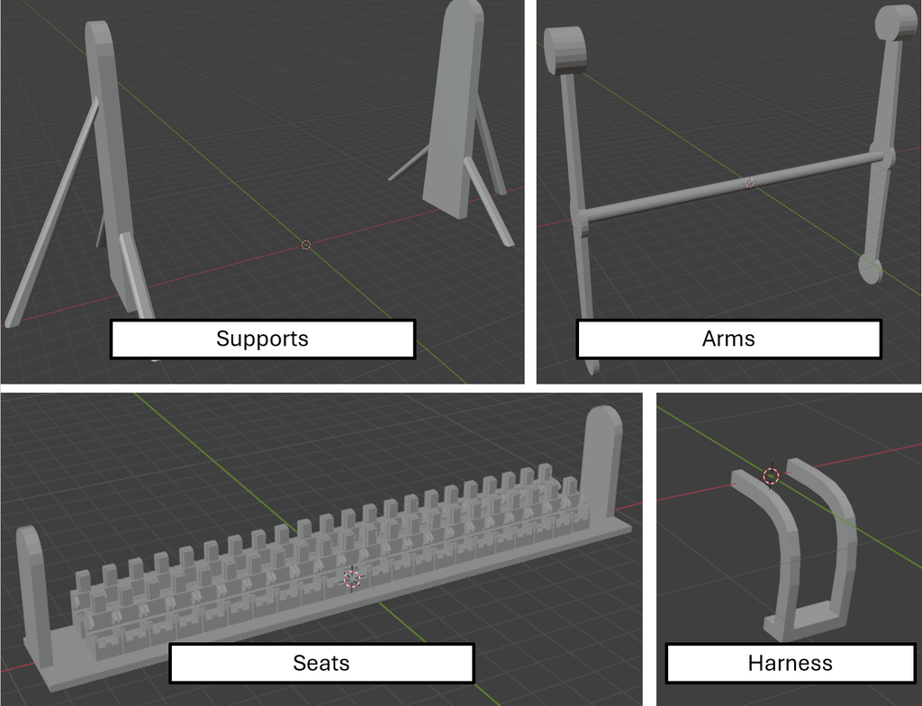

Top Spin Parts

The goal is to draw the ride while it’s going through a ride cycle (animation). By default the individual parts are positioned at the scene origin. Thus, it is your goal to compute the transformation matrix that needs to be applied to each part to move/rotate it into its respective position.

### Animation

The current state of the animation is captured in a `struct` that defines the angles of the respective joints:

```cpp
struct TopSpinState {
    float armAngle; // J1
    float seatsAngle; // J2
    float harnessAngle; // J3
};
```

All angles are measured in degrees. The image below shows what the ride should look like in the initial state where `armAngle=0`, `seatsAngle=0`, `harnessAngle=90` (seats open). The joints are indicated as `J1`, `J2`, `J3` for the `armAngle`, `seatsAngle` and `harnessAngle` respectively. Use the measurements provided in the image in your implementation.

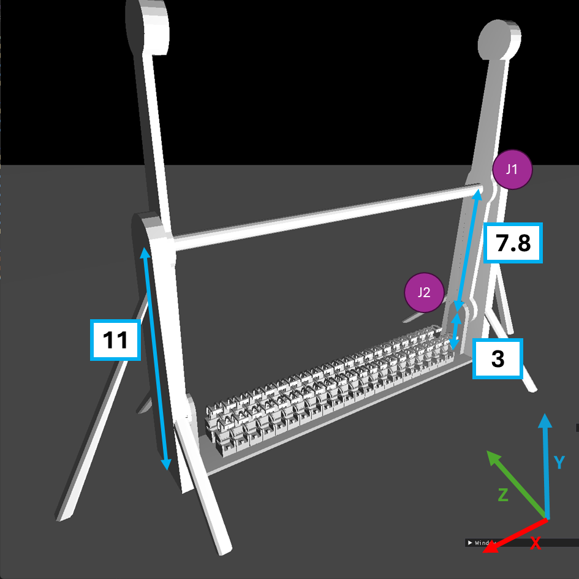

Top Spin Measurements 1

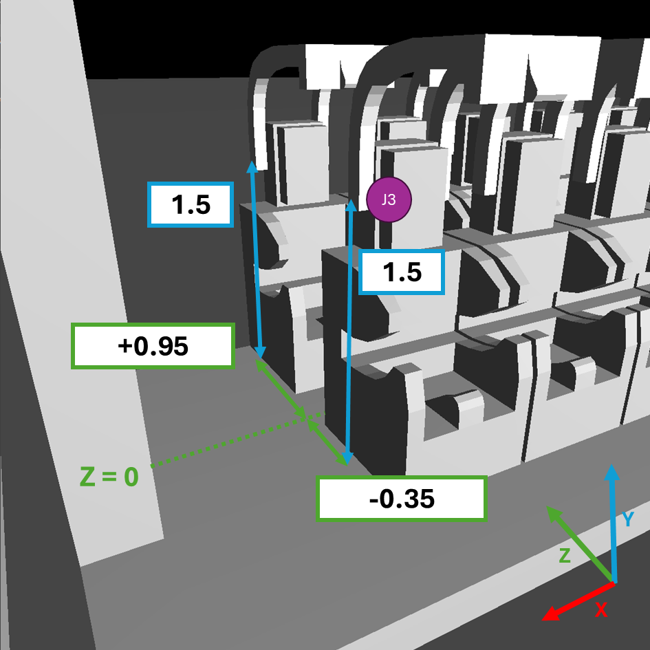

Top Spin Measurements 2

Each seat’s harness is a separate entity, allowing the harness of each seat to be controlled individually. As such, you need to compute a transformation matrix for each harness; two rows of 22 seats. The seats have a width of `0.7` and are equaly spaced between `x=-8` to `x=+8`.

**Note:** - The left- & right most seats should touch `x=+8` and `x=-8` (see illustration below). - The **spacing** between a seat’s center to its neighboring seat’s center is greater than the width of the seat. You are supposed to compute this **spacing** according the description above.

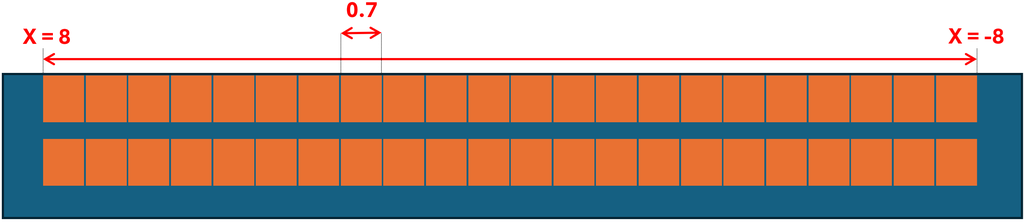

Top Spin Measurements 3

### Implementation

Given the state current state of the top spin (joint angles), you need to compute the matrices required to transform the components into their respective position and orientation. **Implement** `TopSpinMatrices computeTopSpinTransformations(const TopSpinState& topSpinState)` in `amusement_park/src/your_code_here_amusement_park.h`.

The return type of the function is a `struct` containing the matrices that are applied to the supports, arms, seats, and (individual) harnesses. *The matrices of the harnesses may be returned in any order (e.g. left-to-right or right-to-left, front-to-back or back-to-front) as long as each seat has a properly functioning harness.*

You can add your own unit tests in `tests/src/amusement_park.cpp`. A simple test is provided to illustrate the testing framework (Catch2).